# Exposure Tradeoff Thing

This is me playing with numbers. It is not real science. It is certainly not real epidemiology, and no one should take it seriously or follow my advice. I did this to help myself think about the risks associated with various outdoor activities. In particular, the difference between a “distance date” at a park or in a yard with a single friend versus going for a solo walk or bike ride on a populated trail.

You can find the code here.

## Setup

```r
knitr::opts_chunk$set(message = FALSE, warning = FALSE)
library(tidyverse)
theme_set(theme_bw())
```

## Description

### Parameters:

- `prev` is the prevalence of infectious people in the population. It ranges from 1/10 to 1/5000
- `er` is the exposure ratio. It can be thought of as (crowd density * exposure time)/exposure threshold. So, for example, if the threshold amount of exposure required to become infected is 1 hour and you spend 1 hour in the presence of sets of three people *simultaneously*, or 3 hours in the presence of 1 person *at a time*, then your exposure ratio would be 3. It ranges from 1 to 40.
- `n` is the total number of people you are exposed to during your exposure time. For a given exposure ratio, the higher `n` is, the less time you spend with each person. I have `n` ranging from 1 to 500.

Here are some scenarios to elucidate the meanings of the `er` and `n` parameters:

- If it takes 1 hour of exposure to become infected, and I spend 1 hour with 1 person, that gives me an **exposure ratio of 1** and **n of 1**
- If it takes 1 hour of exposure to become infected and I have 4 15-minute meetings back-to-back with 1 person each, then I have an **exposure ratio of 1** again, but an **n of 4**
  - If my 15-minute meetings were with 2 people each then I would have an **exposure ratio of 2** and an **n of 8**
- If it takes 1 hour of exposure to become infected, and I spend 3 hours at a protest where I am only ever exposed to 5 people at a time, but I move around a lot so the total number of people I am exposed to is 50 then I will have an **exposure ratio of 15** (3 hours x 5 people) and an **n of 50**
- If it takes 15 minutes of exposure to become infected and I attend an hour-long meeting with 10 people then I will have an **exposure ratio of 40** and an **n of 10**.
- If it takes 3 hours to get infected and I spend 2 hours continuously in the presence of 1 person at a time, I will have an **exposure ratio of 2/3**
  - Any time exposure ratio is less than 1, the probability of infection is 0, so that situation is excluded from the calculations below
    - Keep in mind that this is actually false. Infection probability would be better modeled as an exponential function of exposure ratio, not a step function. But now we’re veering a little close to real science.

### Calculations:

I iterate through all the parameter values mentioned above. I also set the probability of infection when you’re exposed to a single individual as equal to the prevalence.

In the case of exposure to a single individual, the probability of becoming infected (assuming `er` is at least 1) is equal to the prevalence of the infection in the population.

In the case of multiple shorter exposures to different sets of people, I calculate the threshold number of people required to give a threshold exposure as `n_thresh = n/er`. That is, if my exposure ratio is 2 then I need at least half of the people who I encounter to be infected in order to become infected myself. That is the same as saying I need at least `n/er` people to be infected in order to reach an *effective* exposure ratio of 1.

The probability of at least `n_thresh` hits in a crowd of size `n` is given by the area under the region of the probability density function of a binomial distribution with size n and p = prevalence where hits are greater than or equal to `n_thresh`.

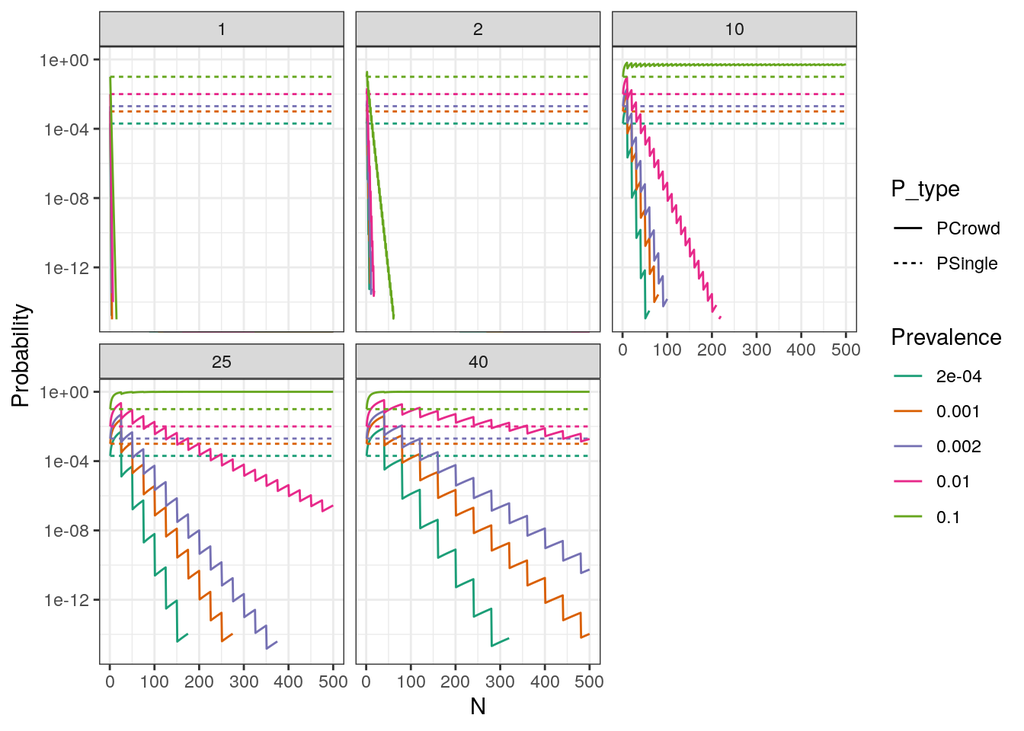

```r
# prevalence of infections in the population
prevs = c(1/10,1/100,1/500,1/1000,1/5000)

# The total number of people you are exposed to during your exposure.
# The higher this number, the less time you spend with each individual
ns = seq(500)

# Exposure ratios
ers = seq(40)

nrows = length(prevs)*length(ns)*length(ers)
res_mat = matrix(nrow = nrows, ncol = 6)
colnames(res_mat) = c('Prevalence', 'ExposureRatio',
                      'N','NThresh','PSingle',
                      'PCrowd')
i = 1
for (prev in prevs){
    for (n in ns){
        for (er in ers){
            p_single = prev
            n_thresh = ceiling(n/er)
            p_crowd = pbinom(n_thresh - 1, n, prev,
                             lower.tail = FALSE)
            res_v = c(prev, er,
                      n, n_thresh, p_single, p_crowd)
            res_mat[i,] = res_v
            i = i + 1
        }
    }
}
res_mat = na.omit(res_mat)
#dim(res_mat)
df = (res_mat
      %>% data.frame())
#head(df)
#summary(df)

#df %>% filter(PCrowd > PSingle, N > 1) %>% summary()

df_long = (df
      %>% gather(P_type, Probability, PSingle, PCrowd))
#head(df_long)
df_plt = (df_long
          %>% filter(ExposureRatio %in% c(1,2,10,25,40))
          %>% mutate_at(c('ExposureRatio','Prevalence'),as.factor))

plt = ggplot(df_plt, aes(N, Probability)) +
    geom_line(aes(colour = Prevalence, linetype = P_type)) +
    facet_wrap(~ExposureRatio) +
    scale_y_continuous(trans = 'log10', limits = c(1e-15,1)) +
    scale_colour_brewer(palette = 'Dark2')
plt
```

```r
pdf('tradeoffs.pdf')
plt
dev.off()
```

## Some facts:

- The jaggedness of the lines is caused by the fact that n_thresh is required to be an integer, so there is rounding happening.
- I limited the plots to regions where the probability of exposure was at least 10^-15.
- When exposure ratio is small, rotating through people drops your risk of infection *fast*. The higher your exposure ratio, the slower that effect is, and if prevalence is high enough, increasing the number of people you are exposed to actually *increases* your chances of exposure.

That box where the exposure ratio is 10 is making me suspicious. Let’s see:

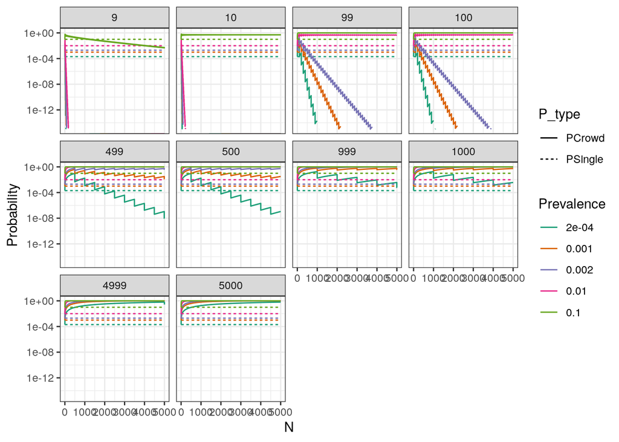

```r
ers = c(9,10,99,100,499,500,999,1000,4999,5000)
ns = seq(5000)

nrows = length(prevs)*length(ns)*length(ers)
res_mat = matrix(nrow = nrows, ncol = 6)
colnames(res_mat) = c('Prevalence', 'ExposureRatio',
                      'N','NThresh','PSingle',
                      'PCrowd')
i = 1
for (prev in prevs){
    for (n in ns){
        for (er in ers){
            p_single = prev
            n_thresh = ceiling(n/er)
            p_crowd = pbinom(n_thresh - 1, n, prev,
                             lower.tail = FALSE)
            res_v = c(prev, er,
                      n, n_thresh, p_single, p_crowd)
            res_mat[i,] = res_v
            i = i + 1
        }
    }
}

res_mat = na.omit(res_mat)
df = (res_mat
      %>% data.frame())

df_long = (df
      %>% gather(P_type, Probability, PSingle, PCrowd))
#head(df_long)
df_plt = (df_long
          %>% mutate_at(c('ExposureRatio','Prevalence'),as.factor))

plt = ggplot(df_plt, aes(N, Probability)) +
    geom_line(aes(colour = Prevalence, linetype = P_type)) +
    facet_wrap(~ExposureRatio) +
    scale_y_continuous(trans = 'log10', limits = c(1e-15,1)) +
    scale_colour_brewer(palette = 'Dark2')
plt
```

```r
pdf('tradeoffs_er_v_prev.pdf', width = 10)
plt
dev.off()
```

So, there’s actual math to be done here but it *seems* like PCrowd will eventually fall below PSingle as long as prevalence is less than 1/exposure ratio, and will approach 1 if pravalence is greater than 1/exposure ratio, and I’m not sure which it does if the two are equal but whatever it does, it does it slowly.

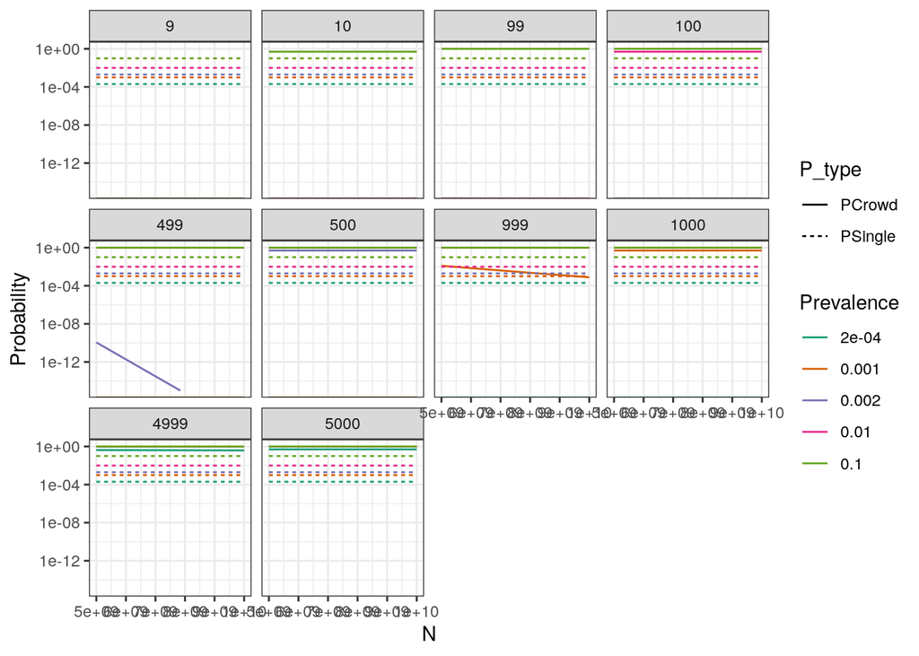

```r
ns = seq(5e9,10e9,1e6)
nrows = length(prevs)*length(ns)*length(ers)
res_mat = matrix(nrow = nrows, ncol = 6)
colnames(res_mat) = c('Prevalence', 'ExposureRatio',
                      'N','NThresh','PSingle',
                      'PCrowd')
i = 1
for (prev in prevs){
    for (n in ns){
        for (er in ers){
            p_single = prev
            n_thresh = ceiling(n/er)
            p_crowd = pbinom(n_thresh - 1, n, prev,
                             lower.tail = FALSE)
            res_v = c(prev, er,
                      n, n_thresh, p_single, p_crowd)
            res_mat[i,] = res_v
            i = i + 1
        }
    }
}

res_mat = na.omit(res_mat)
df = (res_mat
      %>% data.frame())

df_long = (df
      %>% gather(P_type, Probability, PSingle, PCrowd))
#head(df_long)
df_plt = (df_long
          %>% mutate_at(c('ExposureRatio','Prevalence'),as.factor))

plt = ggplot(df_plt, aes(N, Probability)) +
    geom_line(aes(colour = Prevalence, linetype = P_type)) +
    facet_wrap(~ExposureRatio) +
    scale_y_continuous(trans = 'log10', limits = c(1e-15,1)) +
    scale_colour_brewer(palette = 'Dark2')
plt
```

```r
pdf('tradeoffs_er_v_prev_long.pdf', width = 10)
plt
dev.off()
```

Like, really slowly. Maybe it converges on a value less than 1 but greater than PSingle?

```r
summary((df_plt
    %>% filter(Prevalence == 0.1, ExposureRatio == 10,
               P_type == 'PCrowd'))$Probability)
```

```
##    Min. 1st Qu.  Median    Mean 3rd Qu.    Max.
##     0.5     0.5     0.5     0.5     0.5     0.5
```

```r
summary((df_plt
    %>% filter(Prevalence == 0.01, ExposureRatio == 100,
               P_type == 'PCrowd'))$Probability)
```

```
##    Min. 1st Qu.  Median    Mean 3rd Qu.    Max.
##     0.5     0.5     0.5     0.5     0.5     0.5
```

```r
summary((df_plt
    %>% filter(Prevalence == 0.002, ExposureRatio == 500,
               P_type == 'PCrowd'))$Probability)
```

```
##    Min. 1st Qu.  Median    Mean 3rd Qu.    Max.
##     0.5     0.5     0.5     0.5     0.5     0.5
```

K so it’s 1/2.

I bet the math is probably not hard if you know how to do it. I do not know how to do it.

## Conclusions

Possibly counterintuitively:

- Walking/biking along a moderately crowded path where you are constantly passing people is safer than spending that same amount of time sitting in an equivalent proximity to a single random person.
- If you are at a crowded outdoor event (say, a protest) it is probably safer to move around and vary which people you are in proximity to than to spend a lot of time in proximity to the same person or people.
- These guidelines only work if prevalence is fairly low relative to the number of people you’re encountering.

pdfs of plots are here, here, and here